# COVID-19: A Midwestern Reporting Project of WNIN and the University of Evansville

Chicago Zip Code Analysis

Analysis performed by Maya Frederick, Timmy Miller, Ethan Morlock, Pearl Muensterman, and Darrin Weber, Ph.D.

## Background

The goal of this analysis is to find any connections, if they exist, between demographic data and the outbreak of COVID-19 in the city of Chicago. Demographic data was obtained from the Census Bureau through their 5-year American Community Survey published in 2018 (the most recent 5-year data available).

COVID-19 case numbers were obtained from the Illinois Department of Public Health (https://www.dph.illinois.gov/covid19/covid19-statistics)

We see in almost every instance where ZIP code 60604 is an outlier with a case rate of over 5000. There is a considerably smaller population within this ZIP code compared to its neighboring ZIP codes. With this being said, over 80% of ZIP 60604 has been tested for COVID-19 when this is not the case for most ZIP codes.

## Analysis

### COVID

We take a look at the case rate (per 100,000 population) of COVID in the ZIP codes of Chicago, IL.

[interactive chart not shown]

The rate of COVID cases seems pretty well spread out. There is one hotspot location in the 60604 ZIP code, but outside of that ZIP, there is a better distribution than we’ve seen in other cities.

### Family Income in the Past 12 Months

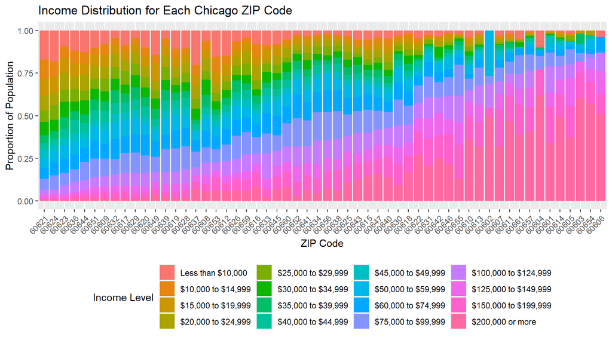

We obtain the income data from the Census Bureau and grouped together those incomes over $100,000. The distribution of incomes between ZIP codes changes in a fairly consistent manner, so focusing on the proportion of six-figure incomes will be a good proxy for the other income brackets. There might be a slight exception to those incomes below $30,000. Ordering the ZIP codes by the proportion of their population which makes below $30,000 would yield a different order than doing the same with six-figure incomes. As a result, we’ll also look at this relationship for incomes below $30,000.

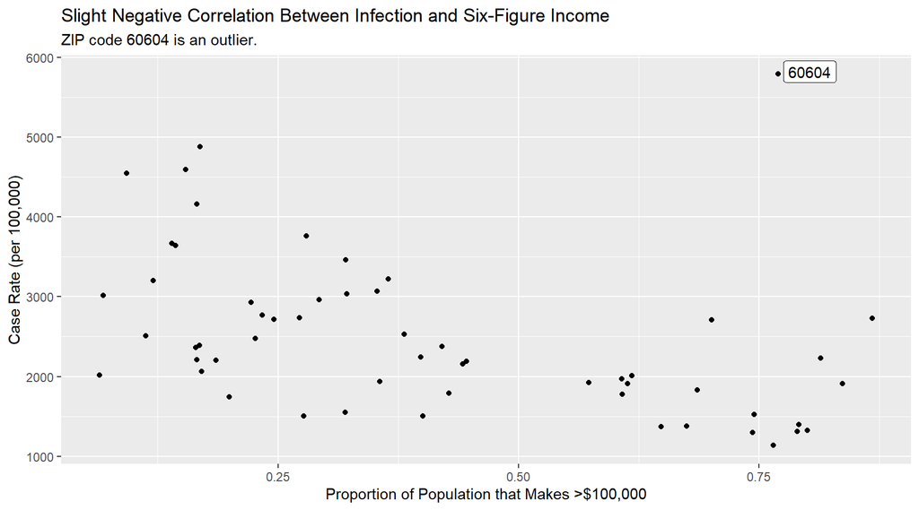

Removing the outlier caused in ZIP code 60604, we see a correlation of -0.5946 and p-value of 0.000001693. This p-value indicates it is statistically significant. There is a moderately strong negative correlation between individuals who make six figures and case rate of COVID.

We now investigate individuals who make 30K and under for its relationship to COVID case rate.

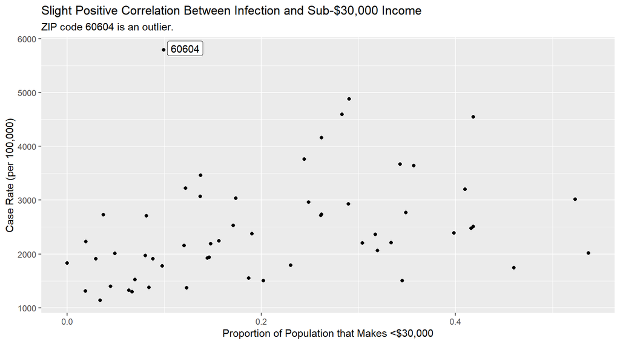

We see a correlation of 0.4214 ($p=$ 0.0014) between incomes of $30,000 and less and case rate. This means that as the proportion of the ZIP code population that makes less than $30,000 increases, so, too, does the case rate of COVID. In other words, there’s a moderate relationship between poorer ZIP codes and higher COVID cases.

### Poverty Status in Past 12 Months by Age

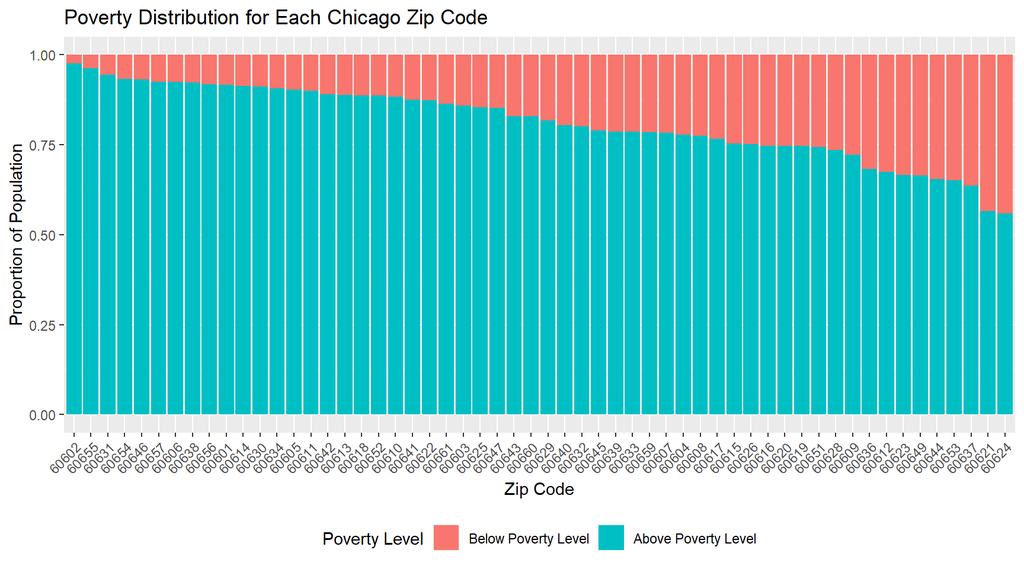

The proportion of the population that lives below the poverty line ranges from about 2.5% to about 44% between ZIP codes.

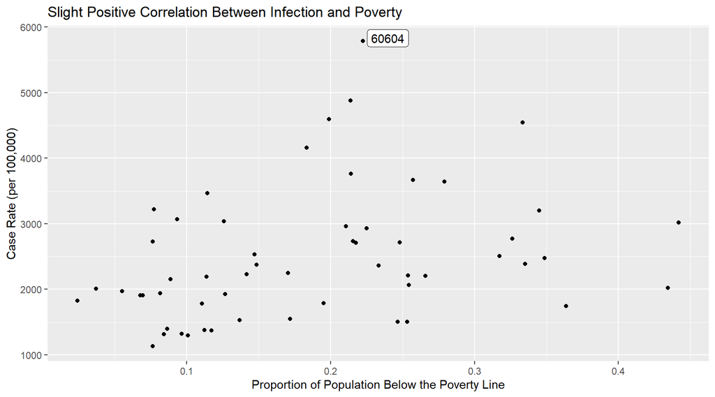

Our scatterplot “fans” out (more spread out) as the proportion of the population below the poverty line increases. This fanning out could have to do with several unknown factors, including a larger difference in reaction in the lower incomes compared to the reaction in the higher income brackets. But this is speculation. We see another p-value which is significant at 0.0188. We have a slight positive correlation between individuals below the poverty line and case rate of 0.3131.

### Occupation by Class of Worker for the Civilian Employed Population 16 Years and Over

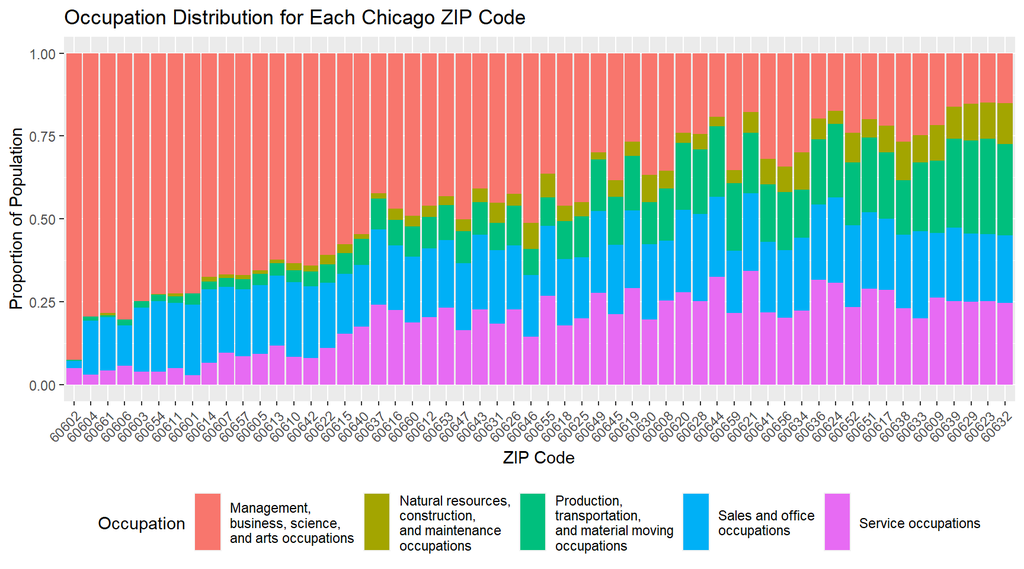

We classify natural resources, construction, and maintenance, as well as production, transportation, and material moving occupations as *essential*, with the other three categories as *non-essential*. This means our ZIP codes range from almost 0% of their population classified as essential workers to 40%.

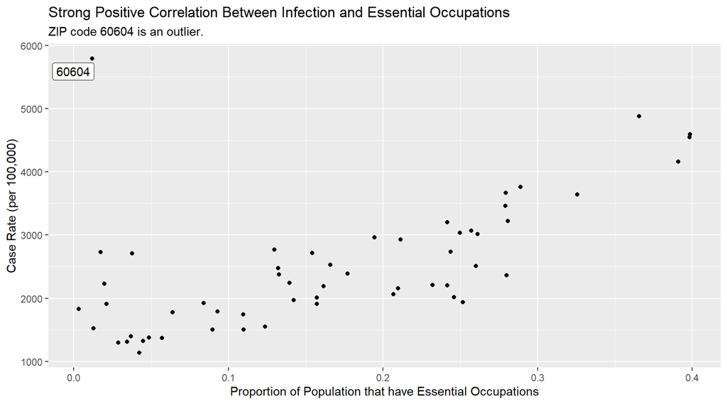

We see our strongest correlation so far comparing essential workers to the number of COVID cases with a correlation value of 0.8186 ($p=$ 0! This means that as the number of essential workers increases, we find a higher the number of COVID cases and vice versa.

### Age

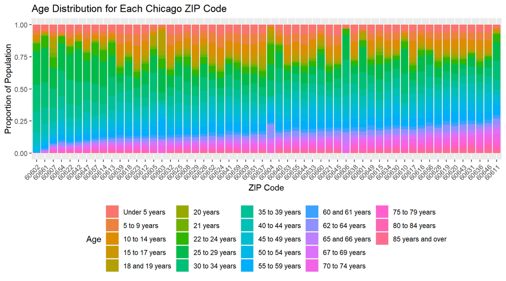

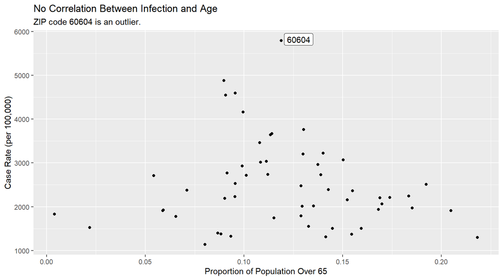

There is a very low correlation of -0.1112 between individuals over the age of 65 and COVID-19 case rates ($p=$ 0.419, which means our correlation is indistinguishable from 0).

### Race

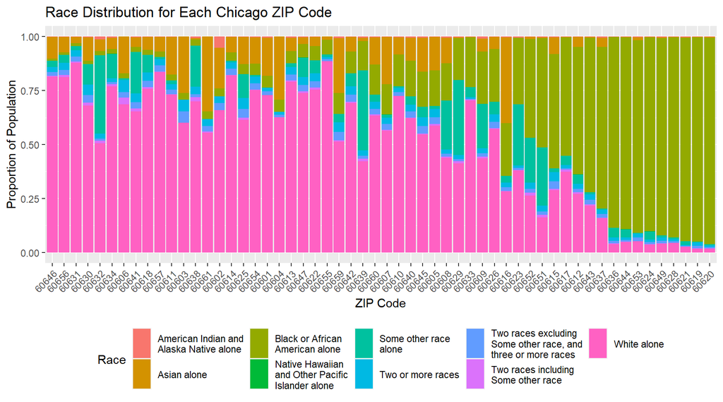

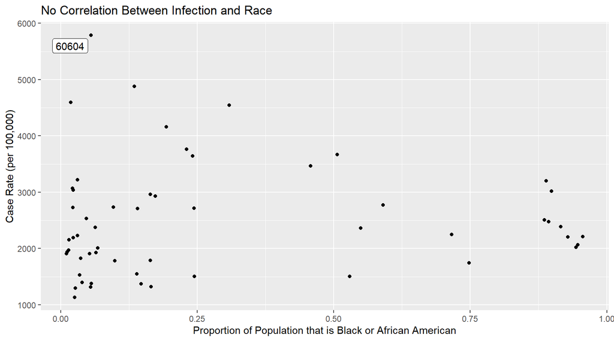

There is a small correlation of 0.0272 ($p=$ 0.8423). This suggests that there is nothing significant between the African American or black race and the case rate of COVID-19.

### Nativity and Citizenship Status in the United States

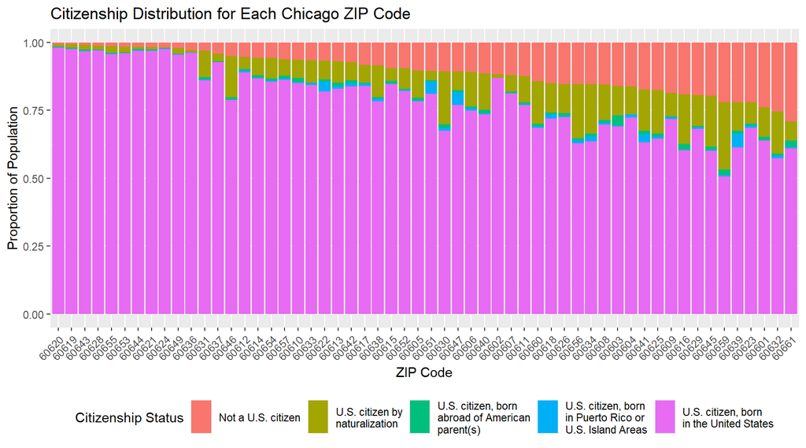

There seems to be a fairly inverse relationship between the proportions of non-citizen and the U.S. born citizen. We focus on the non-citizen population for our analysis.

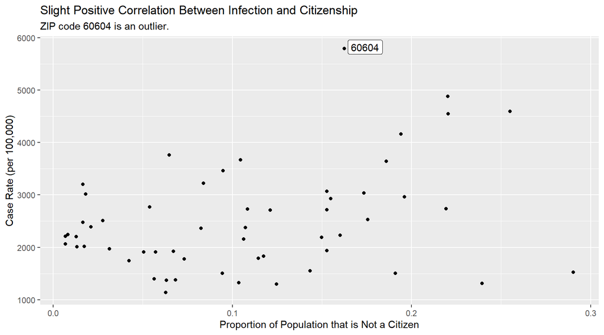

There is a slight positive correlation between individuals with no citizenship and the case rate of COVID-19. With a significant p-value of 0.0192, we have a weak-to-moderate correlation of 0.315.

### Means of Transportation to Work

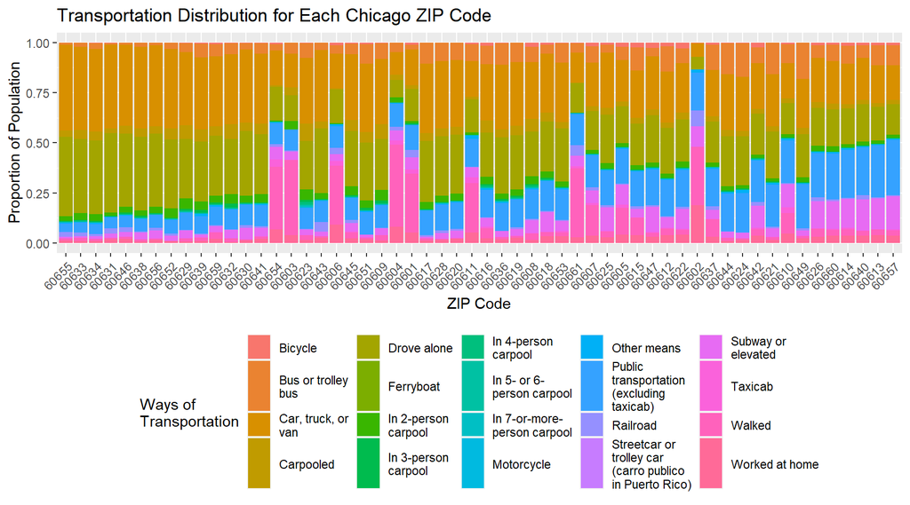

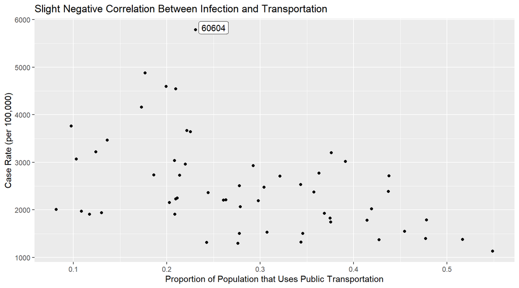

There is a significant p-value of 0.0005 and a slight correlation between individuals who use public transportation and COVID-19 case rates. That correlation is -0.4511. Interpreting the correlation, as more people use pubic transportation and, in Chicago’s case, the L, there are less cases of COVID-19. We used “Public transportation (excluding taxicab)”, “Bus or trolley bus”, “Streetcar or trolley car (carro publico in Puerto Rico)”, “Subway or elevated”, and “Railroad” all for this variable, public transportation.

### Private Health Insurance vs. Public Health Insurance

We look at the prevalence of public and private health insurance throughout the city of Chicago. Since having some type of private health insurance doesn’t preclude you from having public health insurance, we look at both factors as they relate to COVID.

#### Private Health Insurance

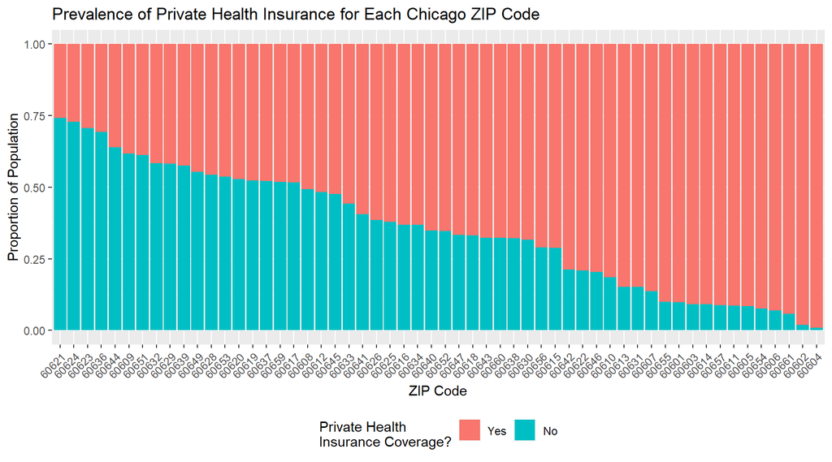

We see a decent range throughout our ZIP codes of the proportion of people who have private health insurance.

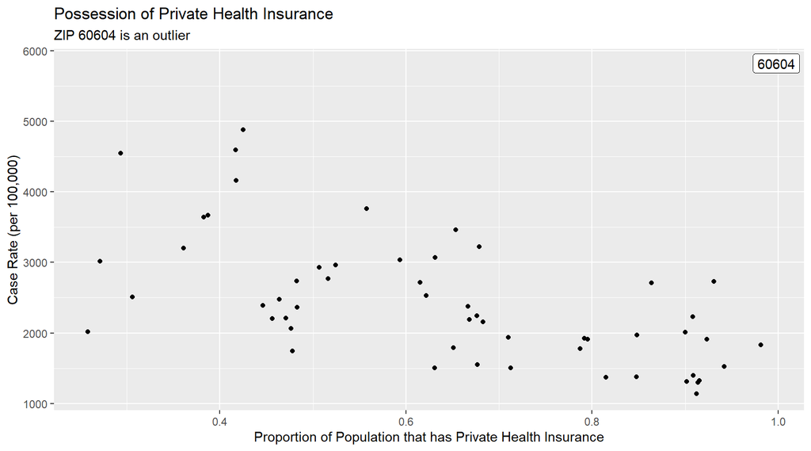

There is a significant correlation of -0.6252 ($p=$ 0). As ZIP codes have more of their population utilizing private health insurance, we find fewer COVID cases.

#### Public Health Insurance

We breakdown each ZIP code by the proportion of residents who have public health insurance.

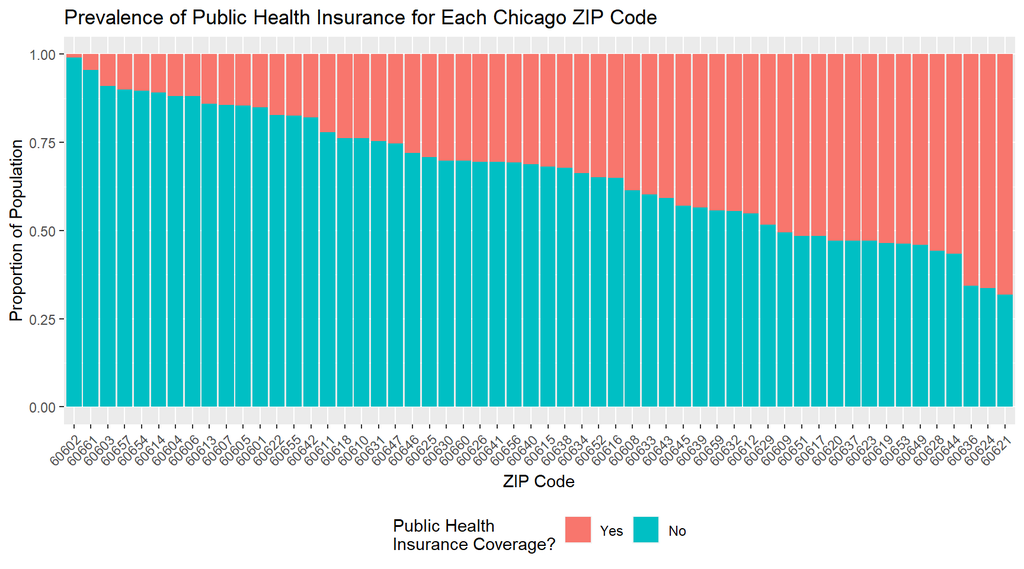

The distribution of the proportion with public health insurance is pretty good, ranging from less than 1% to over 68%.

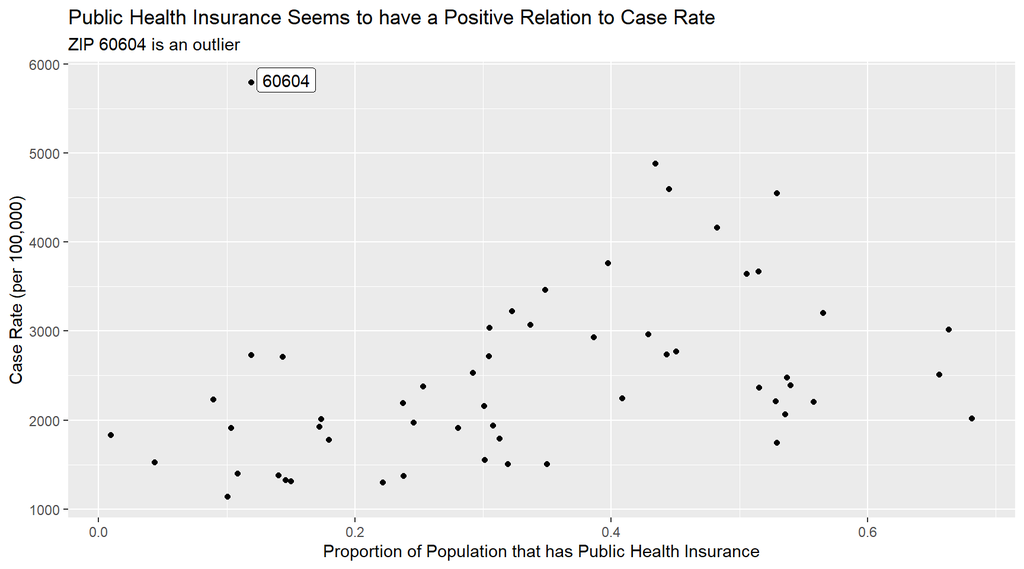

There is a significant p-value and a moderate positive correlation between public health insurance and case rate of 0.4868. This means that we find more COVID cases in ZIP codes that have a higher proportion of their population with public health insurance.

### Gini Index

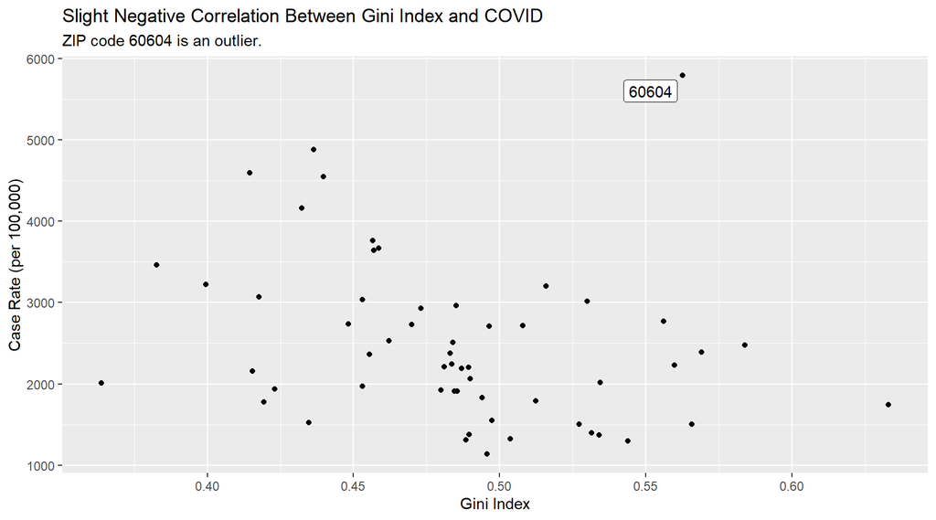

## Conclusions

The ZIP code 60604 is an outlier for many of the comparisons above with its COVID-19 case rate of 5789. This is the highest of all the ZIPs in Chicago. This area is a part of the Chicago “loop” which is full of skyscrapers, entertainment, shops, and parks. We see that over 75% of the individuals living in this area make six figures and over 65% employed have nonessential occupations.

We found many factors that were unsurprising with the way their correlation reflected. For example, we would have expected those who make more money are less impacted by COVID-19. Strong correlation occurred between occupations, distinguished as essential and nonessential. More moderate relationships were found in health insurance type (public vs. private), incomes (higher and lower ends), and public transportation.